# 拍拍贷用户数据探索

加载数据，并对数据进行展示，观察数据集包含的变量以及变量的数据类型

```
## 'data.frame':    328553 obs. of  21 variables:
##  $ ListingId       : int  126541 133291 142421 149711 152141 162641 171191 175451 182261 193831 ...
##  $ 借款金额        : int  18000 9453 27000 25000 20000 20000 3940 20000 25000 10475 ...
##  $ 借款期限        : int  12 12 24 12 6 12 6 12 12 6 ...
##  $ 借款利率        : num  18 20 20 18 16 14 18 18 16 18 ...
##  $ 借款成功日期    : Factor w/ 756 levels "2015-01-01","2015-01-02",..: 119 70 477 84 22 79 172 439 75 100 ...
##  $ 初始评级        : Factor w/ 6 levels "A","B","C","D",..: 3 4 5 3 3 1 5 2 2 3 ...
##  $ 借款类型        : Factor w/ 4 levels "APP闪电","电商",..: 4 4 3 4 2 3 2 3 4 2 ...
##  $ 是否首标        : Factor w/ 2 levels "否","是": 1 1 1 1 1 1 1 1 1 1 ...
##  $ 年龄            : int  35 34 41 34 24 36 27 32 33 25 ...
##  $ 性别            : Factor w/ 2 levels "男","女": 1 1 1 1 1 1 2 1 2 1 ...
##  $ 手机认证        : Factor w/ 2 levels "成功认证","未成功认证": 1 2 1 1 1 1 1 1 1 1 ...
##  $ 户口认证        : Factor w/ 2 levels "成功认证","未成功认证": 2 1 2 1 1 1 1 1 2 1 ...
##  $ 视频认证        : Factor w/ 2 levels "成功认证","未成功认证": 1 2 2 1 1 1 1 1 1 1 ...
##  $ 学历认证        : Factor w/ 2 levels "成功认证","未成功认证": 2 2 2 2 2 2 2 2 2 2 ...
##  $ 征信认证        : Factor w/ 2 levels "成功认证","未成功认证": 2 2 2 2 2 2 2 2 2 2 ...
##  $ 淘宝认证        : Factor w/ 2 levels "成功认证","未成功认证": 2 2 2 2 2 2 2 2 2 2 ...
##  $ 历史成功借款次数: int  11 4 5 6 13 7 15 7 7 9 ...
##  $ 历史成功借款金额: num  40326 14500 21894 36190 77945 ...
##  $ 总待还本金      : num  8713 7891 11726 9703 0 ...
##  $ 历史正常还款期数: int  57 13 25 41 118 56 75 52 41 49 ...
##  $ 历史逾期还款期数: int  16 1 3 1 14 0 8 0 2 4 ...
```

# 数据评估和清洗

ListingId是表格中唯一的主键，统计表格中是否重复的数据，如果存在重复的数据，需要对重复的数据进行删除。

```
## [1] 0
```

表格中不存在重复数据，不需要进行重复数据的清理。

在上面数据展示中看到几款成功日期的数据类型位Factor，将其修改为Date，并进行验证。

```
##  Date[1:328553], format: "2015-05-04" "2015-03-16" "2016-04-26" "2015-03-30" "2015-01-22" ...
```

为了后续的分析创建新的数据特征：

# 单变量绘图选择

## 性别的分布探索

从性别角度探究用户数的分布关系，获取用户画像中性别分布比例，下面绘制性别的用户分布直方图。

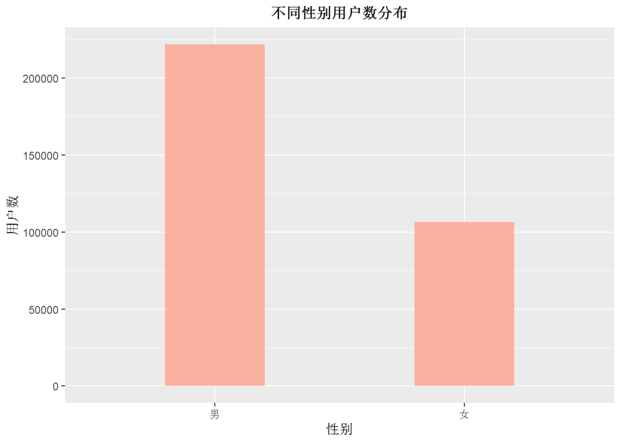

可见，男性用户大于女性。

## 年龄分布探索

年龄是用户画像的一个纬度信息，不同年龄段在某种程度上代表了用户生活的一个阶段，在接下来的分析中首先绘制用户年龄分布直方图来查看用户年龄的分布情况，之后将用户年龄划分为小于18岁、18到22岁、22到25岁、25到28岁、28到35岁、35到40岁、40岁以上来观察不同年龄段用户的分布情况。

用户年龄统计数据:

```
##    Min. 1st Qu.  Median    Mean 3rd Qu.    Max.
##   17.00   24.00   28.00   29.14   33.00   56.00
```

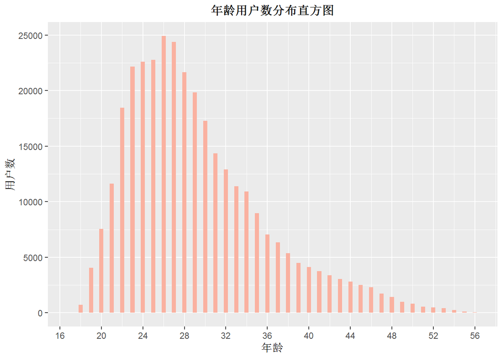

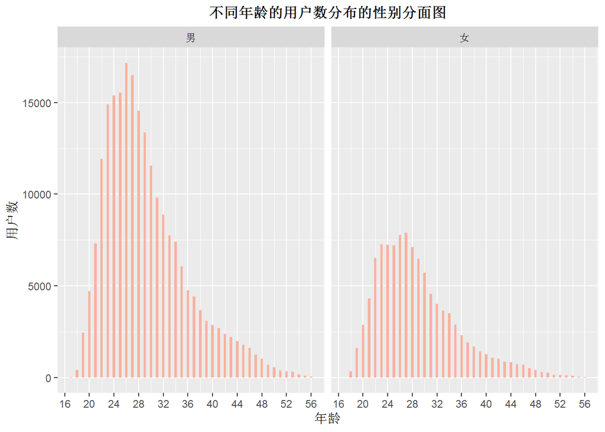

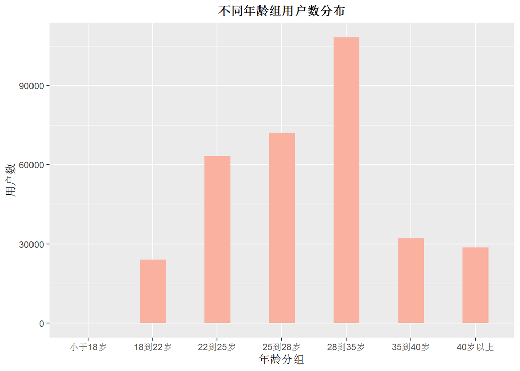

从不同的年龄分组中可以看到，小于18岁的用户数很少，以28到35岁的用户居多，是拍拍贷的主要用户群体。

## 认证分布探索

在拍拍贷的数据集中，记录了用户的手机认证、户口认证、视频认证、学历认证、征信认证和淘宝认证是否成功，认证情况和用户的信用情况有很大的关联性，在接下来的分析中首先查看一下各项认证的用户分布情况，之后在用户各项认证情况中，将用户每完成一项认证得1分，没完成认证得0，将各项认证的得分相加的和，形成认证数新变量，进而探究认证数的用户数分布情况。

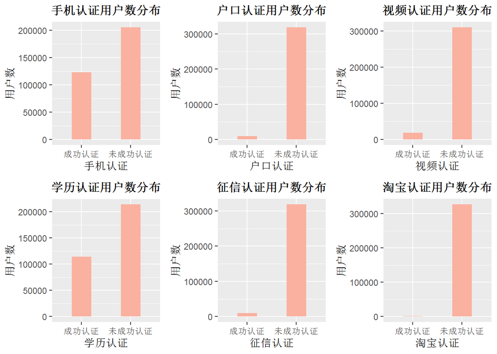

对各项认证进行横向观察，内部的是否完成认证对比可以看到大多数用户都没有完成相关的认证;同时从纵向数据对比可以看到相对来说成功进行手机认证和学历认证的用户数占比相对较高，其他的各项认证中成功进行认证的人数微乎其微。

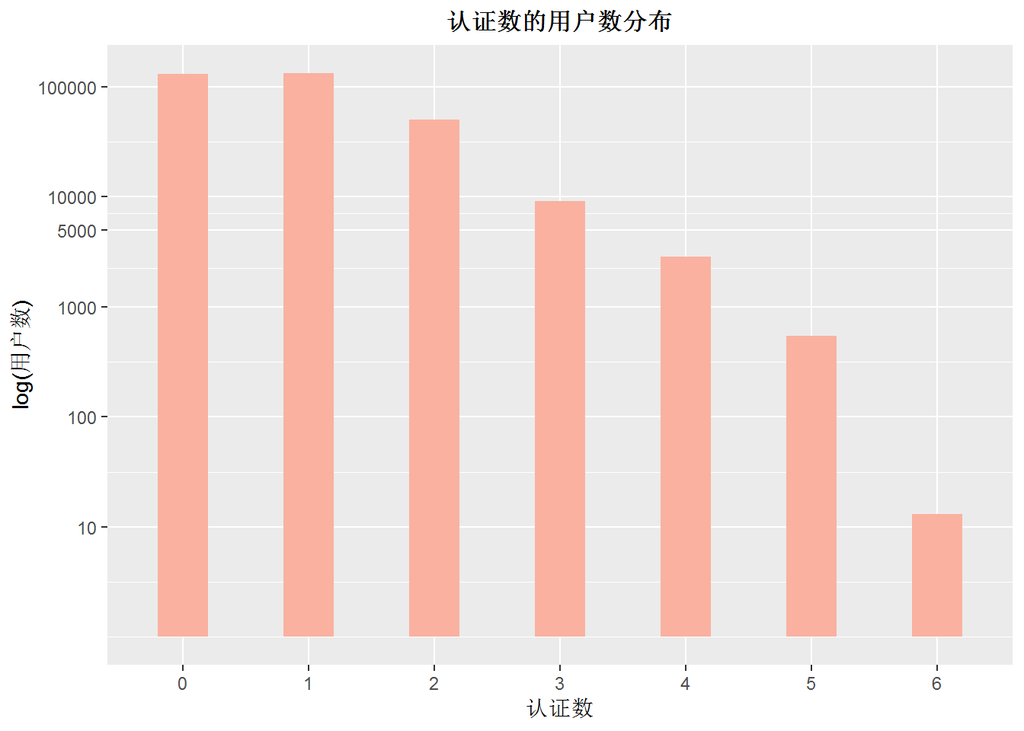

在认证数的用户数量分布在存在数量级上的差异，大多数用户只完成了0、1、2项，只有极少数的用户完成了6项认证。

## 初始评级的用分布

用户初始评级在一定程度反映了用户的信用等级，研究该变量的用户分布，来探究用户信用信息的分布情况。

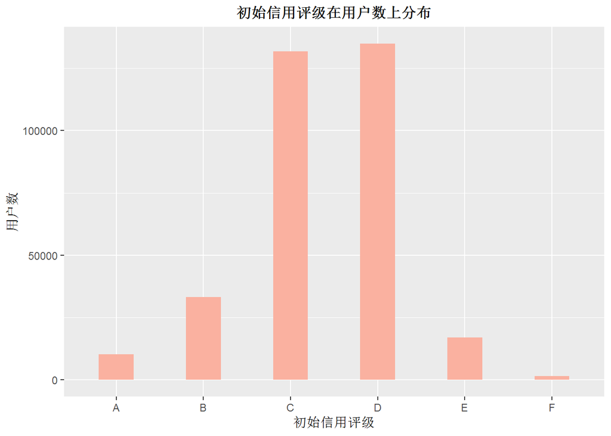

不存在信用等级为AAA和AA的用户，初始信用等级为C和D的用户占绝大多数，其他信用等级的用户极少。

## 是否首标用户分布分析

该订单首标表示这是该客户首次在拍拍贷进行贷款是新增用户，而非首标表示，该用户已经在平台进行过投标时老用户，对是否首标的用户数分布分析可以这段时期内的新用户和老用户的占比。

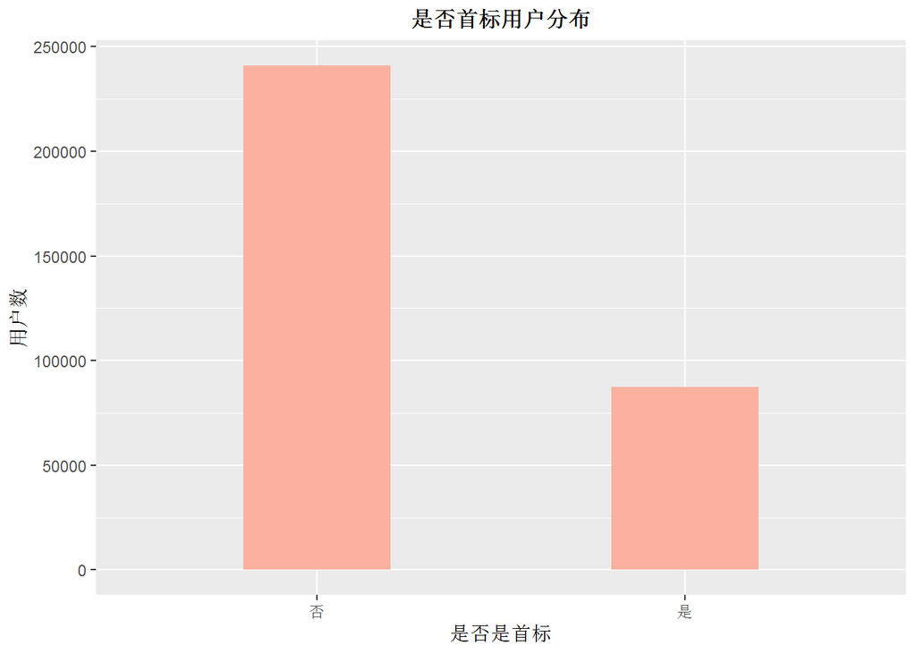

非首标用户远远大于首标用户，说明平台的投标业务大多数是老用户。

## 借款类型的用户数分布

研究不同借款类型的用户数量分布情况。

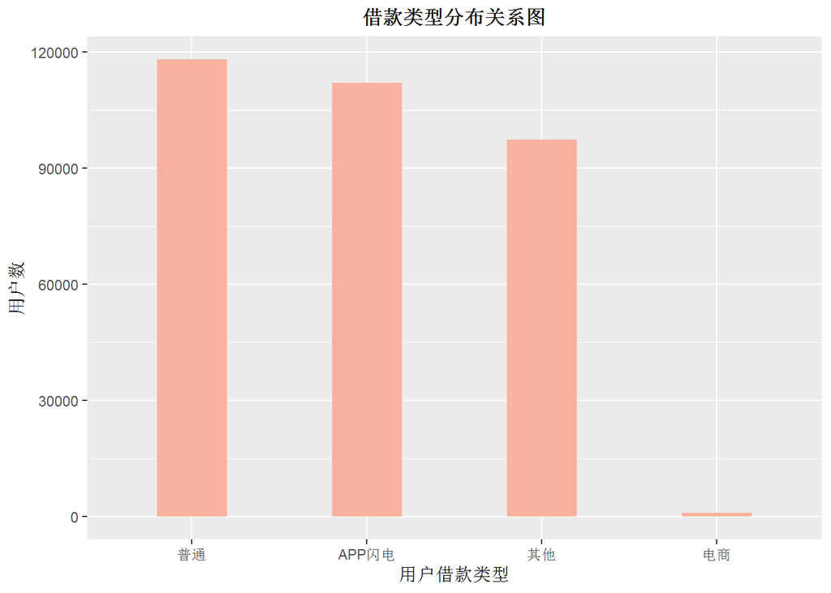

不同的借款类型中，普通用户数量最多，其次是APP闪电，再其次是其他，电商人数最少，其中电商类型的用户数极其少。

## 借款金额的用户分布情况

借款金额的统计信息

```
##    Min. 1st Qu.  Median    Mean 3rd Qu.    Max.
##     100    2033    3397    4424    5230  500000
```

借款金额大于等于50万用户的部分数据展示

```
##        借款金额 age.group 借款利率 auth 初始评级 性别 年龄
## 5391     500000  40岁以上      6.5    0        A   女   52
## 5927     500000  28到35岁     10.0    0        A   男   34
## 6063     500000  35到40岁     10.0    0        A   男   38
## 7377     500000  28到35岁     10.0    0        A   女   33
## 7446     500000  40岁以上     10.0    0        A   女   56
## 7602     500000  40岁以上     10.0    0        A   女   52
## 8481     500000  40岁以上     10.0    0        A   男   40
## 9436     500000  35到40岁      9.0    0        A   男   35
## 12220    500000  28到35岁     14.0    3        B   男   31
## 12277    500000  25到28岁     14.0    2        B   男   25
## 12280    500000  28到35岁     14.0    4        B   男   31
## 12796    500000  35到40岁      9.0    0        A   女   38
## 12986    500000  28到35岁      9.0    0        A   男   34
## 15455    500000  40岁以上     14.0    4        B   男   42
```

[output cut: 42 more lines]

借款金额的最小值为100，最大值为50万，数据呈现长尾分布，对借款金额取log运算并绘制频率多边形图，另外将借款金额划分为1千以下、1千到2千、2千到3千、3千到4千、4千到5千、5千到6千、6千到8千、8千到1万、1万到5万、5万以上几个分组，屏蔽一些不必要的差异信息来观察借款金额的用户分布情况。

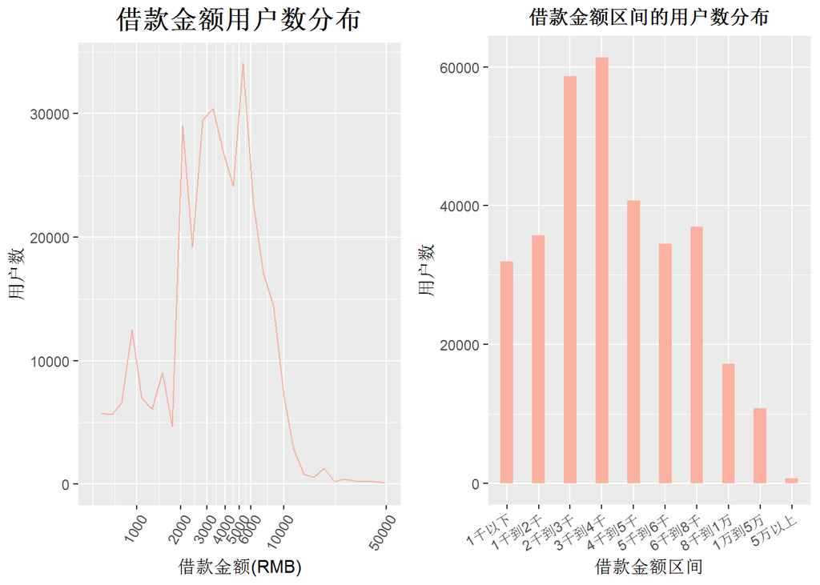

借款金额呈现长尾分布，最小值为100，最大值高达50万，而大多数金额分布在2000到4000，借款金额达到5万以上的人数极少。

## 借款期限用户分布

借款期限统计信息

```
##    Min. 1st Qu.  Median    Mean 3rd Qu.    Max.
##    1.00    6.00   12.00   10.21   12.00   24.00
```

不同借款期限的用户分布，不同借款期限的用户数分布较为离散，将用户的借款期限划分为半年及以下、半年到一年、1到1.5年、1.5到2年几个分组，分别观察各个期限组的用户分布。

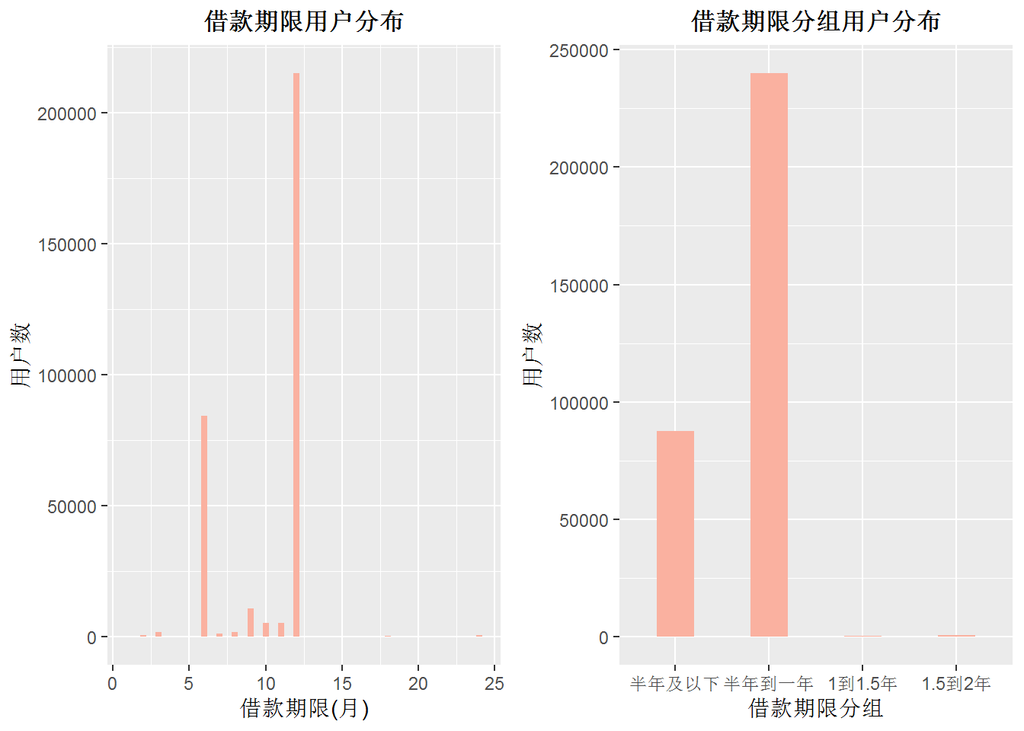

用户的借款期限位于1个月到24个月，不同借款期限的用户数分布较为离散，主要集中在6个月和12个月,绝大多数用户的借款期限是12个月，其次是6个月借款期限，其他借款期限的用户极少；观察不同借款期限分布可以明显看到半年到一年的用户占绝大多数，其次是半年及以下的，其他用户微乎其微。

## 借款利率用户分布

不同借款利率的用户数

```
##
##    6.5      8    8.5      9     10   10.5     11     12     13     14
##      1      1      1     12      9      1      7    589     48    622
##   14.4   14.6     15   15.1   15.8     16     17     18   18.2   18.3
##      1      1    201      6      2  10558     36  38777      1      1
##     19     20   20.2   20.5     21   21.4     22   22.2  22.24   22.3
##     60 126330      1      2    149      1 137899      2      1      1
##   22.4   22.5  22.88     23     24
##      6      1      1   1147  12077
```

借款利率为20和22的用户占总用户数的比例

```
## [1] 0.8042203
```

借款利率统计数据

```
##    Min. 1st Qu.  Median    Mean 3rd Qu.    Max.
##     6.5    20.0    20.0    20.6    22.0    24.0
```

借款利率用户分布箱线图和直方图

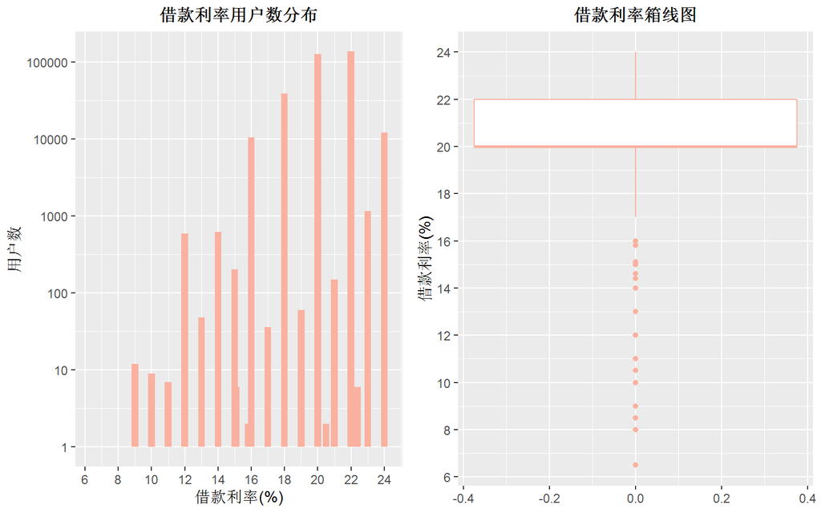

不同的借款利率下，用户数存在数量级上的差异，在对用户数上进行log运算可以更直观地展示用户分布，利率在20到22之间的用户数最多，其中20%和22%用户数量分别126330和137899这样的，这两者已经占到总用户的80.4%。

## 历史成功借款次数用户分布

历史成功借款次数统计数据

```
##    Min. 1st Qu.  Median    Mean 3rd Qu.    Max.
##   0.000   0.000   2.000   2.323   3.000 649.000
```

历史成功借款次数为0的用户占比

```
## [1] 0.2662067
```

[figure not shown]

历史成功借款次数位于0到649，大多数取值为0到3次，其中0占比为26.6%，数据比较分散且误差较小，存在很多的异常点。

## 历史正常还款期数用户分布

历史正常还款期数用户分布统计数据

```
##     Min.  1st Qu.   Median     Mean  3rd Qu.     Max.
##    0.000    0.000    5.000    9.948   13.000 2507.000
```

历史正常还款期数为0的用户占比计算

```
## [1] 0.2716213
```

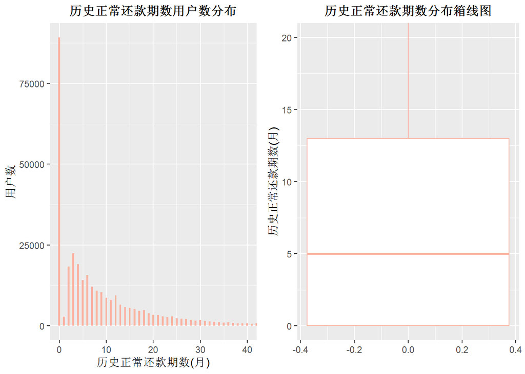

## 历史逾期还款期数用户分布

历史逾期还款期数统计数据

```
##    Min. 1st Qu.  Median    Mean 3rd Qu.    Max.
##  0.0000  0.0000  0.0000  0.4233  0.0000 60.0000
```

历史正常还款期数为0的用户占比：

```
## [1] 0.8466975
```

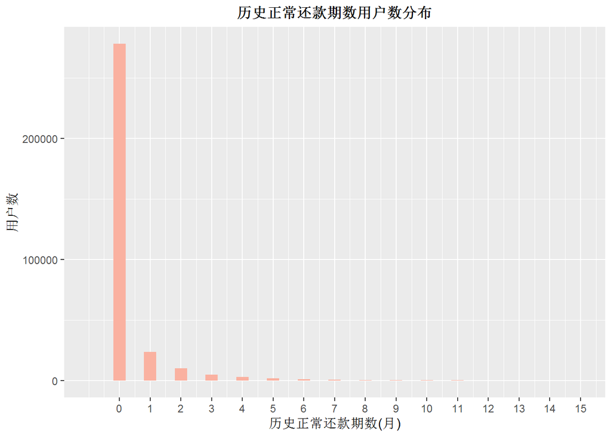

历史逾期还款期数取值范围是0到60，数据主要集中在0处，取值为0的数据占比为84.7%。

## 历史成功借款次数

历史成功借款次数统计数据

```
##    Min. 1st Qu.  Median    Mean 3rd Qu.    Max.
##   0.000   0.000   2.000   2.323   3.000 649.000
```

历史成功借款次数为0的用户占比：

```
## [1] 0.2662067
```

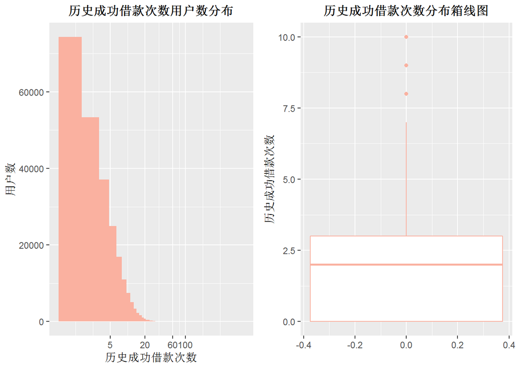

## 违约概率用户数分布

违约概率为0的用户占比

```
## [1] 0.8466975
```

```
## 95%
## 0.5
```

```
##       99%
## 0.6923077
```

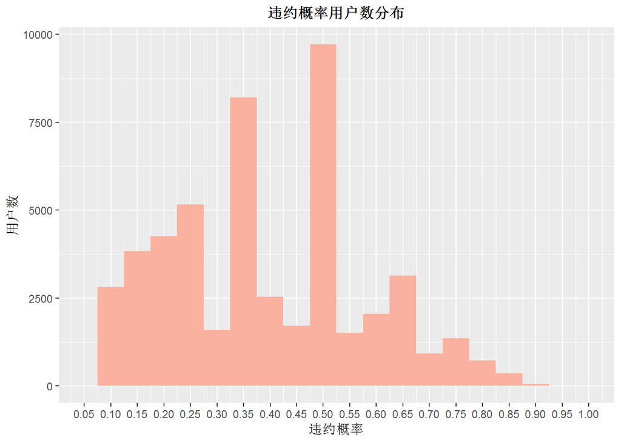

违约概率为0的客户占比为84.7%,违约概率低于0.5的群体占比可达到95%，违约概率低于0.69的客户占比达到99%.

## 违约损失用户分布

违约损失统计数据

```
##     Min.  1st Qu.   Median     Mean  3rd Qu.     Max.
##   0.0000   0.0000   0.7809   1.6556   2.2128 396.1400
```

违约损失为0的用户占比：

```
## [1] 0.3083247
```

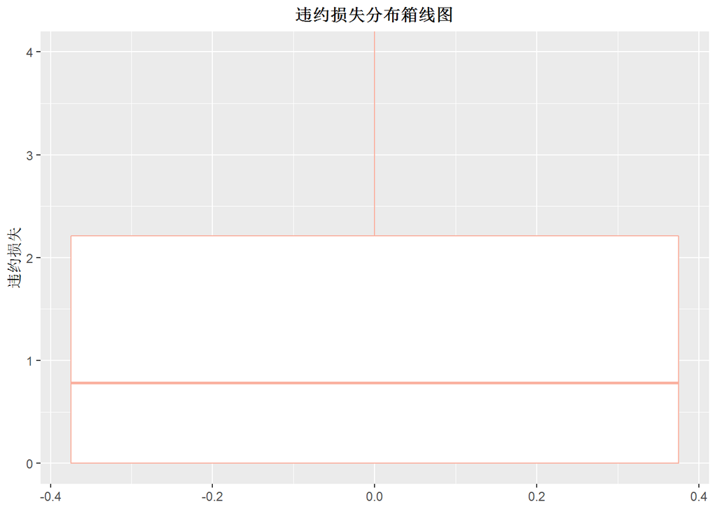

违约损失的分布比较离散，取值范围是0到396.14，中位数是0.78，其中取值为0的用户占比为30.8%，大多数数据位于0到2.2左右，存在很多异常点数据。

# 单变量分析

### 你的数据集结构是什么？

- ListingId：列表序号，为列表的唯一键。
- 借款金额：列表成交总金额。
- 借款期限:总的期数（按月计）。
- 借款利率:年化利率（百分数）
- 借款成功日期:列表成交的日期。都在2015年1月1日以后。
- 初始评级:列表成交时的信用评级。AAA为安全标，AA为赔标，A-F为信用等级。
- 借款类型:分为’应收安全标’，‘电商’，‘APP闪电’，‘普通’和‘其他’。
- 是否首标:该标是否为借款人首标。
- 年龄:借款人在该列表借款成功时的年龄。
- 性别:该列表借款人性别。
- 手机认证:该列表借款人手机实名认证是否成功。
- 户口认证:该列表借款人户口认证是否成功。
- 视频认证:该列表借款人视频认证是否成功。
- 学历认证:该列表借款人学历认证是否成功。
- 征信认证:该列表借款人征信认证是否成功。
- 淘宝认证:该列表借款人淘宝认证是否成功。
- 历史成功借款次数：借款人在该列表成交之前的借款成功次数。
- 历史成功借款金额:借款人在该列表成交之前的借款成功金额。
- 总待还本金:借款人在该列表成交之前待还本金金额。
- 历史正常还款期数:借款人在该列表成交之前的按期还款期数。
- 历史逾期还款期数:借款人在该列表成交之前的逾期还款期数。

### 你的数据集内感兴趣的主要特性有哪些？

- 用户的画像，根据数据的结构探索用户画像可以从
  - 用户的基本信息分析(包含年龄和性别)
  - 信用信息分析(包含初始评级和认证情况)。
- 平台业务情况，平台业务分析主要从
  - 平台业务的基本情况分析(包含借款金额分布、是否首标、借款利率分布、平均利率和初始评级间的关系)
  - 平台业务发展情况(包含借款次数变化、借款金额变化、日新增用户变化)分析两个角度着手。
- 风险分析
  - 违约风险分析(包含违约概率分布,违约损失概率分布)

### 在已经探究的特性中，是否存在任何异常分布？你是否对数据进行一些操作，如清洁、调整或改变数据的形式？如果是，你为什么会这样做？

# 双变量分析

## 借款利率相关因素探究

初始评级和认证数在在一定程度上代表了用户的信用等级，那么平台是否会结合用户的信用等级信息设置不同的贷款利率，分别计算不同信用等级用户的借款利率。

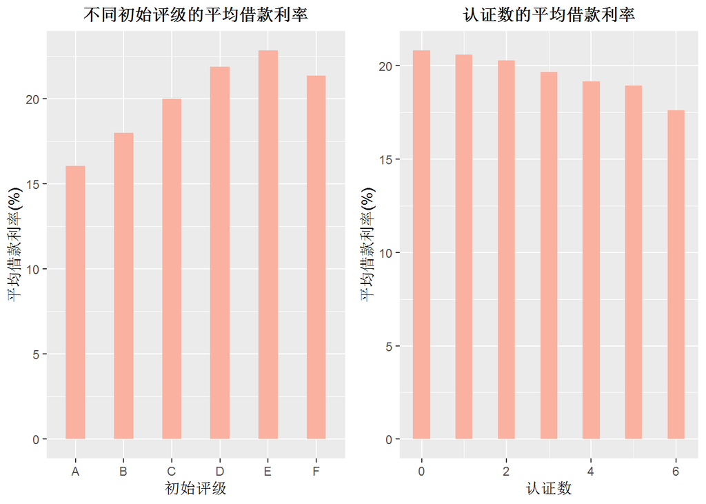

初始评级从A到E随着初始评级的降低，用户的平均借款利率逐渐升高，而在初始评级为F的平均借款利率却低于E时，同时也可以看到无论用户的初始评级如何用户的平均借款利率均查过了15%，而初始评级为C、D、E和F的平均借款利率都超过了20。从认证数的角度，随着认证数的增加，用户的平均借款利率下降。

## 违约率相关因素探究

用户的违约率和性别之间是否有直接的关系，针对性别分别计算相对应的违约率，来研究两者之间的关系。

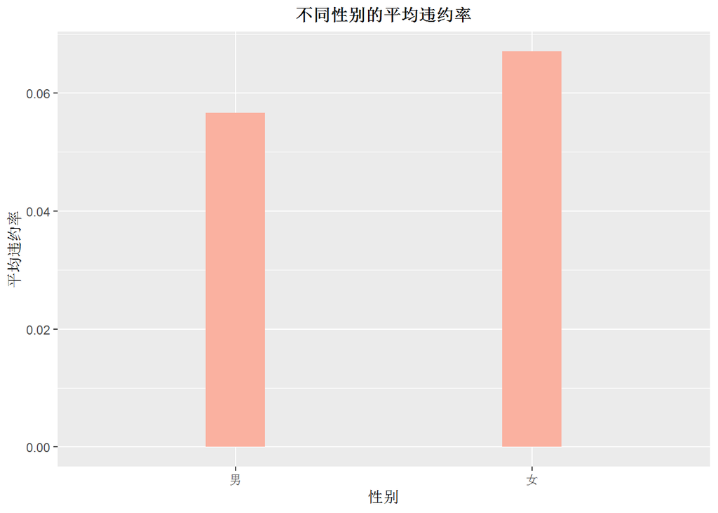

可见女性的平均违约率要高于男性。

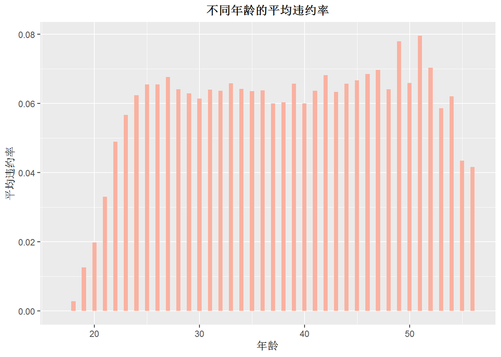

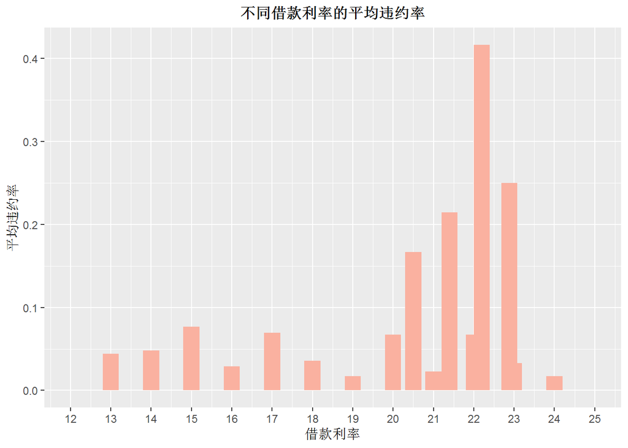

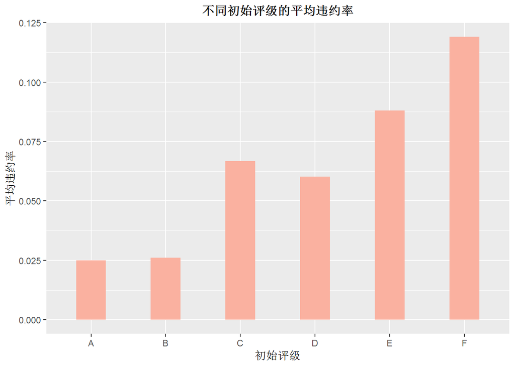

从上图可以看到，大体上初始评级越差平均违约率也越高，其中F等级的违约率最高，其次是E等级，A等级的违约率最低。

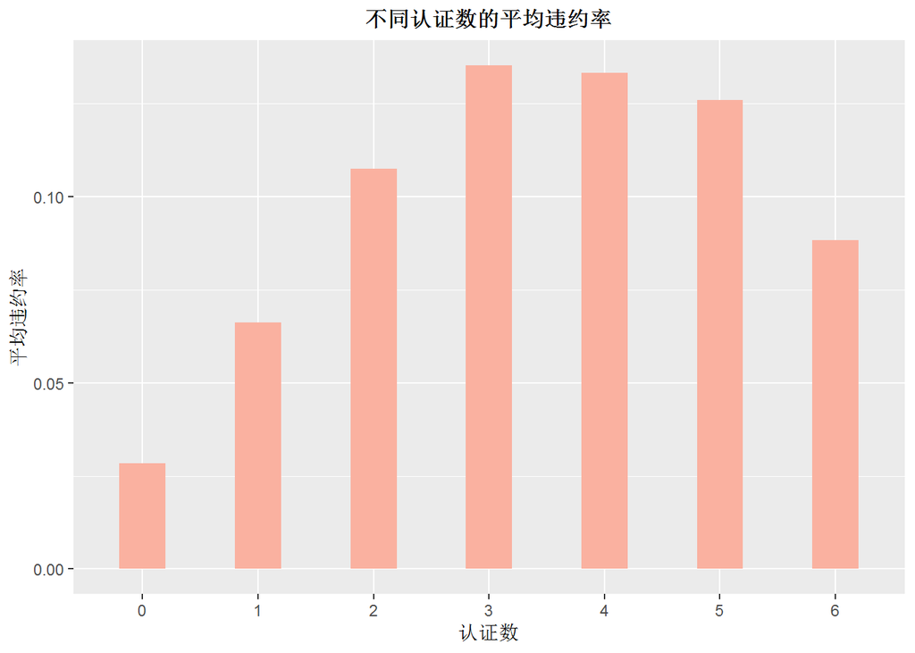

认证数从0到3平均违约率逐渐升高，之后从4到6又逐渐降低，认证数为0的用户的平均违约率最低。

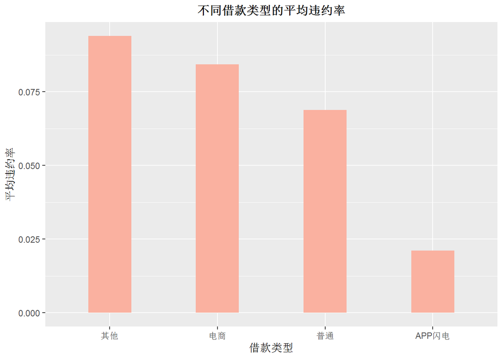

## 违约损失率相关因素探究

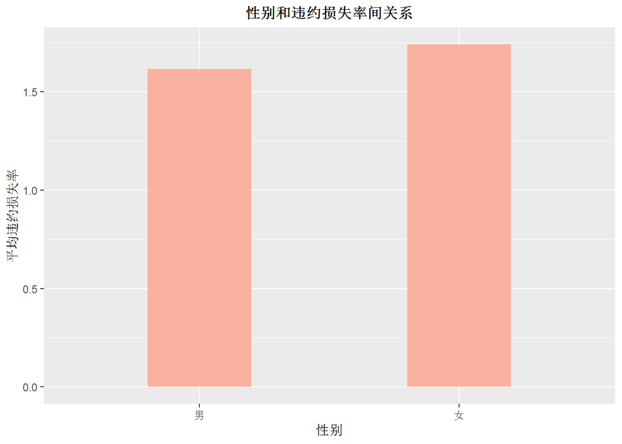

可见女性的平均违约损失率要高于男性。

[figure not shown]

计算年龄大于22岁用户的年龄和违约损失的皮尔森系数：

```
##
##  Pearson's product-moment correlation
##
## data:  sub.LGD.age$age and sub.LGD.age$LGD_mean
## t = -32.249, df = 32, p-value < 2.2e-16
## alternative hypothesis: true correlation is not equal to 0
## 95 percent confidence interval:
##  -0.9925337 -0.9698248
## sample estimates:
##        cor
## -0.9849612
```

18到22岁的违约损失率最低，大于22岁，年龄和违约损失率之间呈现负相关,皮尔森相关系数为-0.985。

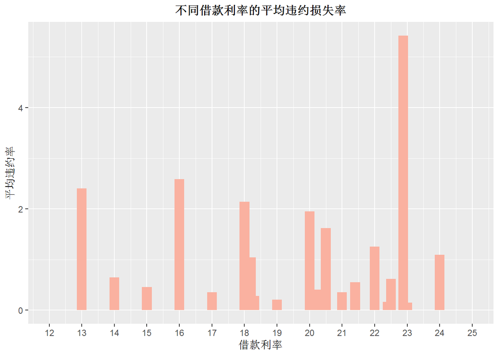

借款利率和违约损失率之间没有明显的相关性。

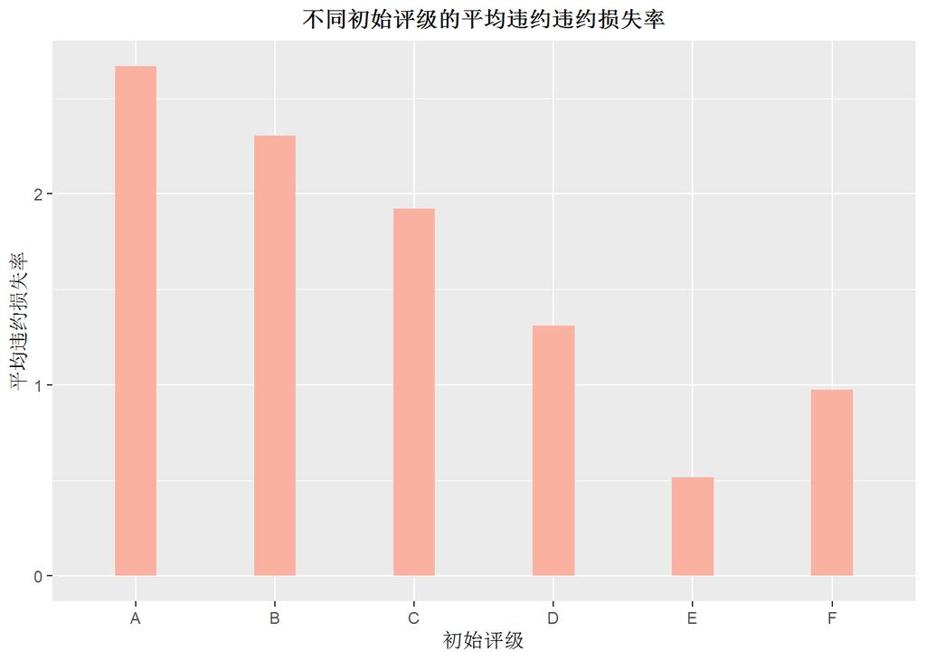

初始登记越高，平均违约损失率也越高。

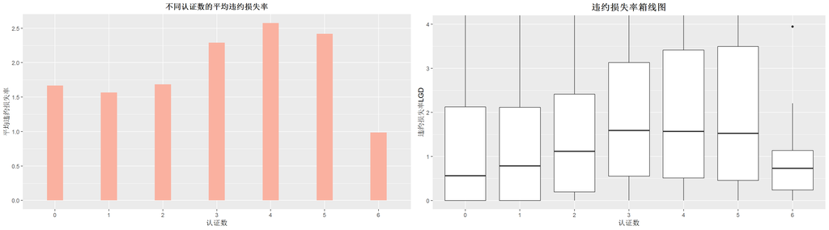

认证数3到5的违约损失率相对较高在2以上，其中认证数为4的平均违约率最高，认证数为6的平均违约率最低。

[figure not shown]